# Prediction Assignment Writeup Coursera

Giorgos Anastasakos

20-6-2019

# Overview

This is a final project for the Coursera “Practical Machine Learning” course.

Background

Using devices such as Jawbone Up, Nike FuelBand, and Fitbit it is now possible to collect a large amount of data about personal activity relatively inexpensively. These type of devices are part of the quantified self movement – a group of enthusiasts who take measurements about themselves regularly to improve their health, to find patterns in their behaviour, or because they are tech geeks. One thing that people regularly do is quantify how much of a particular activity they do, but they rarely quantify how well they do it. In this project, your goal will be to use data from accelerometers on the belt, forearm, arm, and dumbell of 6 participants. They were asked to perform barbell lifts correctly and incorrectly in 5 different ways. More information is available from the website here: http://groupware.les.inf.puc-rio.br/har (see the section on the Weight Lifting Exercise Dataset). Data

The training data for this project are available here:

https://d396qusza40orc.cloudfront.net/predmachlearn/pml-training.csv

The test data are available here:

https://d396qusza40orc.cloudfront.net/predmachlearn/pml-testing.csv

The data for this project come from this source: http://groupware.les.inf.puc-rio.br/har. If you use the document you create for this class for any purpose please cite them as they have been very generous in allowing their data to be used for this kind of assignment.

## Reading the Training and Testing Set and cleaning the data - removing NAs and uneseccary

varilables 1:7 which have no value for the fittin model proccess

```r
pmlTrain <- read.csv(file = "./data/pml-training.csv", header = T)
testQuiz <- read.csv(file ="./data/pml-testing.csv", header = T )
#checking for NAs
any(is.na(testQuiz))
```

```
## [1] TRUE
```

```r
any(is.na(pmlTrain))
```

```
## [1] TRUE
```

```r
#reamoning NAs
pmlTrain<- pmlTrain[, colSums(is.na(pmlTrain)) == 0]
testQuiz <- testQuiz[, colSums(is.na(testQuiz)) == 0]

#removing 1:7 column because the don't have any use
pmlTrain <- pmlTrain[, -c(1:7)]
testQuiz <- testQuiz[, -c(1:7)]
```

## Now i will clear the nearZero Variables.

```r
nearzv <- nearZeroVar(pmlTrain)
pmlTrain <- pmlTrain[,-nearzv]
```

## Making the train and test set from plmTrain

```r
inTrain <- createDataPartition(y = pmlTrain$classe, p=0.7, list = F)

train <- pmlTrain[inTrain,]
test <- pmlTrain[-inTrain,]
```

# Model fit

For the model fit we will try 3 classifing algorithms: *Random Forest* Stochastic Gradient Boosting *k-Nearest Neighbors

*For all three algorthms we will use Cross Validation with the method CV and three folds*

### First will try the Random Forest Algorithm.

```r
set.seed(1234)

controlSplit <- trainControl(method="cv", number=3, verboseIter=FALSE)
modRF <- train(classe ~ ., data=train, method="rf", trControl=controlSplit)
modRF
```

```
## Random Forest
##
## 13737 samples
##    52 predictor
##     5 classes: 'A', 'B', 'C', 'D', 'E'
##
## No pre-processing
## Resampling: Cross-Validated (3 fold)
## Summary of sample sizes: 9160, 9157, 9157
## Resampling results across tuning parameters:
##
##   mtry  Accuracy   Kappa
##    2    0.9874064  0.9840681
##   27    0.9882075  0.9850812
##   52    0.9831122  0.9786347
##
## Accuracy was used to select the optimal model using the largest value.
## The final value used for the model was mtry = 27.
```

```r
predRF <- predict(modRF, test)
confusionMatrix(predRF, test$classe)
```

```
## Confusion Matrix and Statistics
##
##           Reference
## Prediction    A    B    C    D    E
##          A 1672    9    0    0    0
##          B    1 1125    7    0    0
##          C    0    4 1015   13    2
##          D    0    1    4  951    5
##          E    1    0    0    0 1075
##
## Overall Statistics
##
##                Accuracy : 0.992
##                  95% CI : (0.9894, 0.9941)
##     No Information Rate : 0.2845
##     P-Value [Acc > NIR] : < 2.2e-16
##
##                   Kappa : 0.9899
##  Mcnemar's Test P-Value : NA
##
## Statistics by Class:
##
##                      Class: A Class: B Class: C Class: D Class: E
## Sensitivity            0.9988   0.9877   0.9893   0.9865   0.9935
## Specificity            0.9979   0.9983   0.9961   0.9980   0.9998
## Pos Pred Value         0.9946   0.9929   0.9816   0.9896   0.9991
## Neg Pred Value         0.9995   0.9971   0.9977   0.9974   0.9985
## Prevalence             0.2845   0.1935   0.1743   0.1638   0.1839
## Detection Rate         0.2841   0.1912   0.1725   0.1616   0.1827
## Detection Prevalence   0.2856   0.1925   0.1757   0.1633   0.1828
## Balanced Accuracy      0.9983   0.9930   0.9927   0.9922   0.9967
```

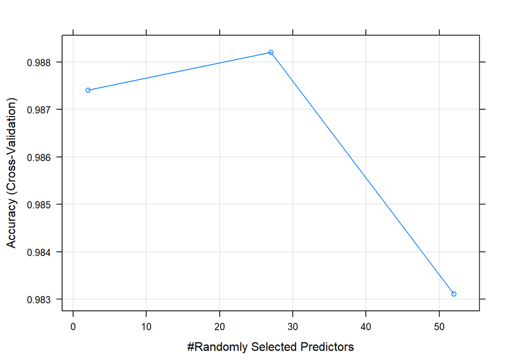

```r
plot(modRF)
```

```r
varImp(modRF)
```

```
## rf variable importance
##
##   only 20 most important variables shown (out of 52)
##
##                      Overall
## roll_belt            100.000
## pitch_forearm         58.947
## yaw_belt              55.020
## magnet_dumbbell_z     43.658
## pitch_belt            42.514
## magnet_dumbbell_y     42.325
## roll_forearm          39.035
## accel_dumbbell_y      21.459
## magnet_dumbbell_x     18.563
## roll_dumbbell         17.057
## accel_forearm_x       16.975
## magnet_belt_z         15.238
## total_accel_dumbbell  14.292
## accel_dumbbell_z      13.524
## accel_belt_z          13.221
## magnet_belt_y         13.113
## magnet_forearm_z      12.946
## yaw_arm               10.830
## gyros_belt_z          10.587
## magnet_belt_x          9.727
```

### The second algorithm that will try is the Stochastic Gradient Boosting

```r
set.seed(1234)
controlSplit <- trainControl(method="cv", number=3, verboseIter=FALSE)
modGBM <- train(classe ~ ., data=train, method="gbm", trControl=controlSplit, verbose = FALSE)
modGBM
```

```
## Stochastic Gradient Boosting
##
## 13737 samples
##    52 predictor
##     5 classes: 'A', 'B', 'C', 'D', 'E'
##
## No pre-processing
## Resampling: Cross-Validated (3 fold)
## Summary of sample sizes: 9160, 9157, 9157
## Resampling results across tuning parameters:
##
##   interaction.depth  n.trees  Accuracy   Kappa
##   1                   50      0.7479071  0.6803845
##   1                  100      0.8188117  0.7707057
##   1                  150      0.8532444  0.8143138
##   2                   50      0.8582678  0.8204435
##   2                  100      0.9099521  0.8860146
##   2                  150      0.9301889  0.9116533
##   3                   50      0.8967033  0.8692034
##   3                  100      0.9415460  0.9260175
##   3                  150      0.9598897  0.9492479
##
## Tuning parameter 'shrinkage' was held constant at a value of 0.1
##
## Tuning parameter 'n.minobsinnode' was held constant at a value of 10
## Accuracy was used to select the optimal model using the largest value.
## The final values used for the model were n.trees = 150,
##  interaction.depth = 3, shrinkage = 0.1 and n.minobsinnode = 10.
```

```r
predGBM <- predict(modGBM, test)
confusionMatrix(predGBM, test$classe)
```

```
## Confusion Matrix and Statistics
##
##           Reference
## Prediction    A    B    C    D    E
##          A 1639   40    0    0    2
##          B   23 1063   36    2    8
##          C    5   35  968   40    7
##          D    5    0   19  914   20
##          E    2    1    3    8 1045
##
## Overall Statistics
##
##                Accuracy : 0.9565
##                  95% CI : (0.951, 0.9616)
##     No Information Rate : 0.2845
##     P-Value [Acc > NIR] : < 2.2e-16
##
##                   Kappa : 0.945
##  Mcnemar's Test P-Value : 7.584e-05
##
## Statistics by Class:
##
##                      Class: A Class: B Class: C Class: D Class: E
## Sensitivity            0.9791   0.9333   0.9435   0.9481   0.9658
## Specificity            0.9900   0.9855   0.9821   0.9911   0.9971
## Pos Pred Value         0.9750   0.9390   0.9175   0.9541   0.9868
## Neg Pred Value         0.9917   0.9840   0.9880   0.9899   0.9923
## Prevalence             0.2845   0.1935   0.1743   0.1638   0.1839
## Detection Rate         0.2785   0.1806   0.1645   0.1553   0.1776
## Detection Prevalence   0.2856   0.1924   0.1793   0.1628   0.1799
## Balanced Accuracy      0.9846   0.9594   0.9628   0.9696   0.9814
```

### The last method that we will use is the k-Nearest Neighbors.

```r
set.seed(1234)
controlSplit <- trainControl(method="cv", number=3, verboseIter=FALSE)

modKnn <- train(classe ~ ., data=train, method="knn", trControl=controlSplit,preProcess = c("center", "scale"))
modKnn
```

```
## k-Nearest Neighbors
##
## 13737 samples
##    52 predictor
##     5 classes: 'A', 'B', 'C', 'D', 'E'
##
## Pre-processing: centered (52), scaled (52)
## Resampling: Cross-Validated (3 fold)
## Summary of sample sizes: 9160, 9157, 9157
## Resampling results across tuning parameters:
##
##   k  Accuracy   Kappa
##   5  0.9405268  0.9247446
##   7  0.9267681  0.9072998
##   9  0.9138106  0.8909027
##
## Accuracy was used to select the optimal model using the largest value.
## The final value used for the model was k = 5.
```

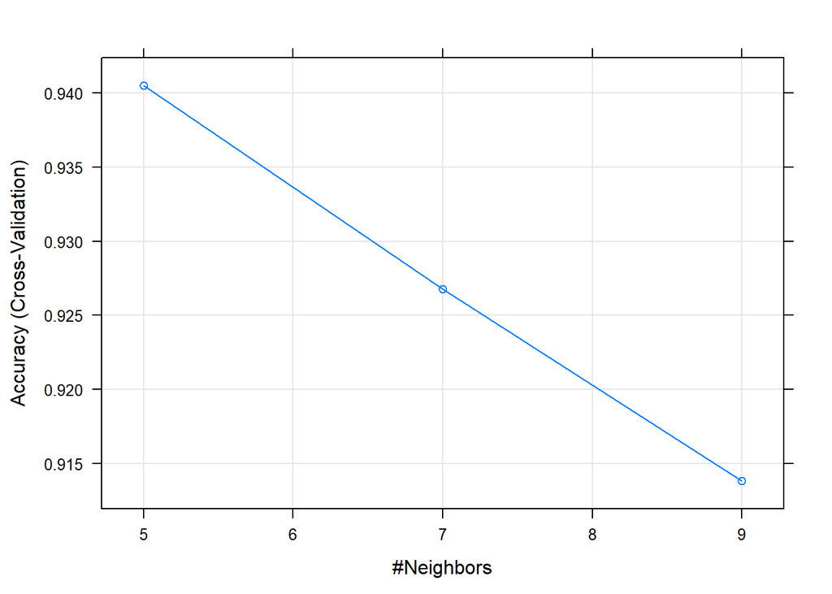

```r
plot(modKnn)
```

```r
predKnn <- predict(modKnn, test)
confusionMatrix(predKnn, test$classe)
```

```
## Confusion Matrix and Statistics
##
##           Reference
## Prediction    A    B    C    D    E
##          A 1635   26    1    2    1
##          B   15 1065   19    0    6
##          C   12   37  980   43    7
##          D   10    7   15  919    4
##          E    2    4   11    0 1064
##
## Overall Statistics
##
##                Accuracy : 0.9623
##                  95% CI : (0.9571, 0.967)
##     No Information Rate : 0.2845
##     P-Value [Acc > NIR] : < 2.2e-16
##
##                   Kappa : 0.9523
##  Mcnemar's Test P-Value : 3.274e-07
##
## Statistics by Class:
##
##                      Class: A Class: B Class: C Class: D Class: E
## Sensitivity            0.9767   0.9350   0.9552   0.9533   0.9834
## Specificity            0.9929   0.9916   0.9796   0.9927   0.9965
## Pos Pred Value         0.9820   0.9638   0.9082   0.9623   0.9843
## Neg Pred Value         0.9908   0.9845   0.9904   0.9909   0.9963
## Prevalence             0.2845   0.1935   0.1743   0.1638   0.1839
## Detection Rate         0.2778   0.1810   0.1665   0.1562   0.1808
## Detection Prevalence   0.2829   0.1878   0.1833   0.1623   0.1837
## Balanced Accuracy      0.9848   0.9633   0.9674   0.9730   0.9899
```

### Now we will use the carot function resamples in order to choice the best model for the

prediction.

```r
#resamples

resamps <- resamples(list(RF = modRF, GBM=modGBM, KNN =modKnn))
summary(resamps)
```

```
##
## Call:
## summary.resamples(object = resamps)
##
## Models: RF, GBM, KNN
## Number of resamples: 3
##
## Accuracy
##          Min.   1st Qu.    Median      Mean   3rd Qu.      Max. NA's
## RF  0.9860262 0.9872271 0.9884279 0.9882075 0.9892981 0.9901682    0
## GBM 0.9582969 0.9590611 0.9598253 0.9598897 0.9606861 0.9615469    0
## KNN 0.9351528 0.9376638 0.9401747 0.9405268 0.9432138 0.9462530    0
##
## Kappa
##          Min.   1st Qu.    Median      Mean   3rd Qu.      Max. NA's
## RF  0.9823230 0.9838411 0.9853592 0.9850812 0.9864604 0.9875615    0
## GBM 0.9472398 0.9481989 0.9491579 0.9492479 0.9502520 0.9513461    0
## KNN 0.9179243 0.9211105 0.9242967 0.9247446 0.9281547 0.9320127    0
```

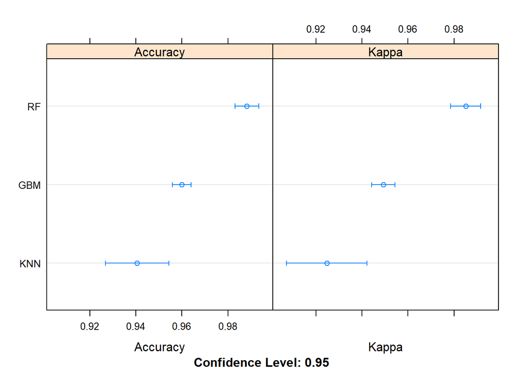

```r
dotplot(resamps)
```

# It’s obvious that Random Forest is the best model for the current data set.

```r
predQuetRF <- predict(modRF, testQuiz)
predQuetRF
```

```
##  [1] B A B A A E D B A A B C B A E E A B B B
## Levels: A B C D E
```